# CASE 2 - Jhon Heider Domingos Rezende

Second - The construction of the model is based on in a optimal lag selection and it establishes the possible relations between each one of the series inputted into the model. The correspond tests (normality, arch effects and presence of autocorrelation) for confirm the stability of the model is also presented bellow.

Thrid - In this phase we calculate the Impulse Response Function (IRF for short) for each series in each model to measure the response of a specific variable given a shock in other variable related with the first one. We also calculate the Granger Causality that presents the null hypothesis whether one time series is useful in forecasting another. Then we make the predictions for each series.

```r
##### VAR MODEL - DATA PRE PROCESSING #####

library(openxlsx)

# file reading
covariates = read.xlsx("covariates.xlsx")

# Annual observations from 1997 to 2019
covariates = covariates[19:41,]

# Only exports
data = df
data = data[which(data$type=="Export"),]

# Separate the products
sb = data[which(data$product=="soybeans"),]
sb_meal = data[which(data$product=="soybean_meal"),]
corn = data[which(data$product=="corn"),]

# Tons by month
sb = tapply(sb$tons, sb$date, FUN = sum)
sb_meal = tapply(sb_meal$tons, sb_meal$date, FUN = sum)
corn = tapply(corn$tons, corn$date, FUN = sum)

# Convert to time series object
sb = ts(sb, start = c(1997,1), end = c(2019,12), frequency = 12)
sb_meal = ts(sb_meal, start = c(1997,1), end = c(2019,12), frequency = 12)
corn = ts(corn, start = c(1997,1), end = c(2019,12), frequency = 12)

### Seasonal Adjustment

# Seasonal adjustment for Corn
adjust = seas(corn)
adjust
qs(adjust)

corn = final(adjust)

# Seasonal adjustment for Soybeans meal
adjust = seas(sb_meal)
adjust
qs(adjust)

sb_meal = final(adjust)

# Seasonal adjustment for Soybeans
adjust = seas(sb)
adjust
qs(adjust)

sb = final(adjust)

# Convert to a xts data frame
DtEx = seq(as.Date("1997-01-01"), as.Date("2019-12-01"), by = "month")
data = data.frame(DtEx, sb, sb_meal, corn)
data = xts(data[,-1], order.by = data[,1])

# Corn annual observations exports
corn = data$corn
corn = as.numeric(corn)
corn = rollapply(corn, width = 12, by = 12, align = "lef", FUN = "sum")
corn = ts(corn, start = c(1997,12), end = c(2019,12), frequency = 1)

# Soybeans annual observations exports
sb = data$sb
sb = as.numeric(sb)
sb = rollapply(sb, width = 12, by = 12, align = "lef", FUN = "sum")
sb = ts(sb, start = c(1997,12), end = c(2019,12), frequency = 1)

# Soybeans annual observations exports
sbm = data$sb_meal
sbm = as.numeric(sbm)
sbm = rollapply(sbm, width = 12, by = 12, align = "lef", FUN = "sum")
sbm = ts(sbm, start = c(1997,12), end = c(2019,12), frequency = 1)


# Covariates to ts
price_corn = ts(covariates$price_corn,start = c(1997,12), end = c(2019,12), frequency = 1)
price_sb = ts(covariates$price_soybeans,start = c(1997,12), end = c(2019,12), frequency = 1)
price_sbm = ts(covariates$price_soybean_meal,start = c(1997,12), end = c(2019,12), frequency = 1)
gdp_nether = ts(covariates$gpd_netherlands,start = c(1997,12), end = c(2019,12), frequency = 1)
gdp_thail = ts(covariates$gdp_thailand,start = c(1997,12), end = c(2019,12), frequency = 1)
gdp_iran = ts(covariates$gdp_iran, start = c(1997,12), end = c(2019,12), frequency = 1)
gdp_spain = ts(covariates$gdp_spain, start = c(1997,12), end = c(2019,12), frequency = 1)
gdp_world = ts(covariates$gdp_world, start = c(1997,12), end = c(2019,12), frequency = 1)
gdp_vietnam = ts(covariates$gdp_vietnam, start = c(1997,12), end = c(2019,12), frequency = 1)
gdp_japan = ts(covariates$gdp_japan, start = c(1997,12), end = c(2019,12), frequency = 1)
gdp_egypt = ts(covariates$gdp_egypt, start = c(1997,12), end = c(2019,12), frequency = 1)
gdp_china = ts(covariates$gdp_china, start = c(1997,12), end = c(2019,12), frequency = 1)

# Main partners Soybeans and Soybeans meal

# Last 3 years
data = df
data$date <- as.Date(data$date, format= "%Y-%m-%d")

data = subset(data, date>= "2017-01-01" & date <= "2019-12-01")

# Only exports
data = data[which(data$type=="Export"),]

# Corn and sugar
sb1 = data[which(data$product=="soybeans"),]
sb_meal = data[which(data$product=="soybean_meal"),]

## Main brazilian trade partners of the previous two products


# Soybeans partners
sb_partners = tapply(sb1$tons, sb1$country, FUN = sum)
sb_partners = sort(sb_partners, decreasing = TRUE)
country = row.names(sb_partners)
sb_partners = cbind(country, sb_partners)
sb_partners = as.data.frame(sb_partners)
colnames(sb_partners) = c("Country", "Tons")

# SBM partners
sbm_partners = tapply(sb_meal$tons, sb_meal$country, FUN = sum)
sbm_partners = sort(sbm_partners, decreasing = TRUE)
country = row.names(sbm_partners)
sbm_partners = cbind(country, sbm_partners)
sbm_partners = as.data.frame(sbm_partners)
colnames(sbm_partners) = c("Country", "Tons")

# Soybeans: China, Spain, Thailand, Netherlands
# Soybean Meal: Netherlands, Thailand, South Korea, France

rm(adjust, country, covariates, DtEx, sb1, sb_meal, sb_partners, sbm_partners)
```

```r
#### CORN - VAR MODEL #####

# Bind the variables
vars = cbind(corn/1000, price_corn, gdp_japan, gdp_egypt)

# Rename the created data set
colnames(vars) = c("Corn", "Price Corn", "GDP Japan", "GDP Egypt")

# Building the optimal lags
lagselect = VARselect(vars, lag.max = 20, type = "both")
lagselect$selection # One lag
```

```
## AIC(n)  HQ(n)  SC(n) FPE(n)
##      1      1      1      1
```

```r
# Model
ModelVAR_Corn = VAR(vars, p = 1, type = "both", season = NULL, exogen = NULL)
summary(ModelVAR_Corn)
```

```
##
## VAR Estimation Results:
## =========================
## Endogenous variables: Corn, Price.Corn, GDP.Japan, GDP.Egypt
## Deterministic variables: both
## Sample size: 22
## Log Likelihood: -419.418
## Roots of the characteristic polynomial:
## 0.9975 0.6244 0.2981 0.1736
## Call:
## VAR(y = vars, p = 1, type = "both", exogen = NULL)
##
##
## Estimation results for equation Corn:
## =====================================
## Corn = Corn.l1 + Price.Corn.l1 + GDP.Japan.l1 + GDP.Egypt.l1 + const + trend
##
##                 Estimate Std. Error t value Pr(>|t|)
## Corn.l1       -3.195e-01  3.467e-01  -0.922    0.370
## Price.Corn.l1  3.898e+00  3.181e+01   0.123    0.904
## GDP.Japan.l1   3.440e+02  3.918e+02   0.878    0.393
## GDP.Egypt.l1   1.770e+02  1.214e+02   1.458    0.164
## const         -9.810e+04  7.882e+04  -1.245    0.231
## trend         -1.688e+03  2.234e+03  -0.756    0.461
##
##
## Residual standard error: 5494 on 16 degrees of freedom
## Multiple R-Squared: 0.7741,  Adjusted R-squared: 0.7036
## F-statistic: 10.97 on 5 and 16 DF,  p-value: 0.0001024
##
##
## Estimation results for equation Price.Corn:
## ===========================================
## Price.Corn = Corn.l1 + Price.Corn.l1 + GDP.Japan.l1 + GDP.Egypt.l1 + const + trend
##
##                 Estimate Std. Error t value Pr(>|t|)
## Corn.l1       -3.080e-03  1.819e-03  -1.693  0.10981
## Price.Corn.l1  7.754e-01  1.669e-01   4.645  0.00027 ***
## GDP.Japan.l1   5.709e-01  2.056e+00   0.278  0.78481
## GDP.Egypt.l1   1.594e-01  6.372e-01   0.250  0.80569
```

[output cut: 50 more lines]

```
##
##
## Covariance matrix of residuals:
##                Corn Price.Corn GDP.Japan GDP.Egypt
## Corn       30186509  -57708.20  6583.757  3069.111
## Price.Corn   -57708     831.03    14.405   -23.505
## GDP.Japan      6584      14.41     6.404     3.873
## GDP.Egypt      3069     -23.50     3.873    22.200
##
## Correlation matrix of residuals:
##               Corn Price.Corn GDP.Japan GDP.Egypt
## Corn        1.0000    -0.3644    0.4735    0.1186
## Price.Corn -0.3644     1.0000    0.1975   -0.1731
## GDP.Japan   0.4735     0.1975    1.0000    0.3248
## GDP.Egypt   0.1186    -0.1731    0.3248    1.0000
```

```r
## Diagnostics
serial.test(ModelVAR_Corn, lags.pt = 12, type = "PT.asymptotic")
```

```
##
##  Portmanteau Test (asymptotic)
##
## data:  Residuals of VAR object ModelVAR_Corn
## Chi-squared = 156.25, df = 176, p-value = 0.8552
```

```r
# Heterocedasticity
arch.test(ModelVAR_Corn, lags.multi = 10, multivariate.only = TRUE)
```

```
##
##  ARCH (multivariate)
##
## data:  Residuals of VAR object ModelVAR_Corn
## Chi-squared = 120, df = 1000, p-value = 1
```

```r
# Normality Distribution of residuals
normality.test(ModelVAR_Corn, multivariate.only = TRUE)
```

```
## $JB
##
##  JB-Test (multivariate)
##
## data:  Residuals of VAR object ModelVAR_Corn
## Chi-squared = 6.3687, df = 8, p-value = 0.606
##
##
## $Skewness
##
##  Skewness only (multivariate)
##
## data:  Residuals of VAR object ModelVAR_Corn
## Chi-squared = 3.0943, df = 4, p-value = 0.5422
##
##
## $Kurtosis
##
##  Kurtosis only (multivariate)
##
## data:  Residuals of VAR object ModelVAR_Corn
## Chi-squared = 3.2743, df = 4, p-value = 0.513
```

[figure not shown]

```r
# Testing for structural breaks in the residuals
stab = stability(ModelVAR_Corn, type = "OLS-CUSUM")
plot(stab)
```

```r
# Granger causality
causality(ModelVAR_Corn, cause = "Corn")
```

```
## $Granger
##
##  Granger causality H0: Corn do not Granger-cause Price.Corn GDP.Japan
##  GDP.Egypt
##
## data:  VAR object ModelVAR_Corn
## F-Test = 1.2738, df1 = 3, df2 = 64, p-value = 0.2909
##
##
## $Instant
##
##  H0: No instantaneous causality between: Corn and Price.Corn GDP.Japan
##  GDP.Egypt
##
## data:  VAR object ModelVAR_Corn
## Chi-squared = 7.0205, df = 3, p-value = 0.07125
```

```r
causality(ModelVAR_Corn, cause = "Price.Corn")
```

```
## $Granger
##
##  Granger causality H0: Price.Corn do not Granger-cause Corn GDP.Japan
##  GDP.Egypt
##
## data:  VAR object ModelVAR_Corn
## F-Test = 3.3666, df1 = 3, df2 = 64, p-value = 0.02387
##
##
## $Instant
##
##  H0: No instantaneous causality between: Price.Corn and Corn GDP.Japan
##  GDP.Egypt
##
## data:  VAR object ModelVAR_Corn
## Chi-squared = 6.1014, df = 3, p-value = 0.1068
```

```r
causality(ModelVAR_Corn, cause = "GDP.Japan")
```

```
## $Granger
##
##  Granger causality H0: GDP.Japan do not Granger-cause Corn Price.Corn
##  GDP.Egypt
##
## data:  VAR object ModelVAR_Corn
## F-Test = 2.965, df1 = 3, df2 = 64, p-value = 0.03856
##
##
## $Instant
##
##  H0: No instantaneous causality between: GDP.Japan and Corn Price.Corn
##  GDP.Egypt
##
## data:  VAR object ModelVAR_Corn
## Chi-squared = 7.2423, df = 3, p-value = 0.06456
```

```r
causality(ModelVAR_Corn, cause = "GDP.Egypt")
```

```
## $Granger
##
##  Granger causality H0: GDP.Egypt do not Granger-cause Corn Price.Corn
##  GDP.Japan
##
## data:  VAR object ModelVAR_Corn
## F-Test = 8.8108, df1 = 3, df2 = 64, p-value = 5.669e-05
##
##
## $Instant
##
##  H0: No instantaneous causality between: GDP.Egypt and Corn Price.Corn
##  GDP.Japan
##
## data:  VAR object ModelVAR_Corn
## Chi-squared = 3.7194, df = 3, p-value = 0.2934
```

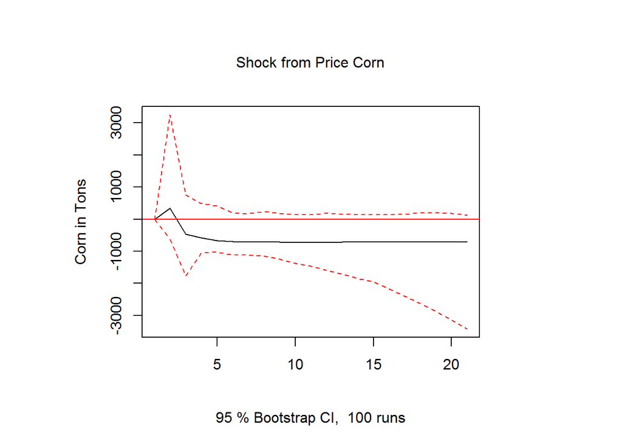

```r
# Impulse response function
pricecorn_IRF = irf(ModelVAR_Corn, impulse = "Price.Corn", response = "Corn", n.ahead = 20, boot = TRUE)
plot(pricecorn_IRF, ylab = "Corn in Tons", main = "Shock from Price Corn")
```

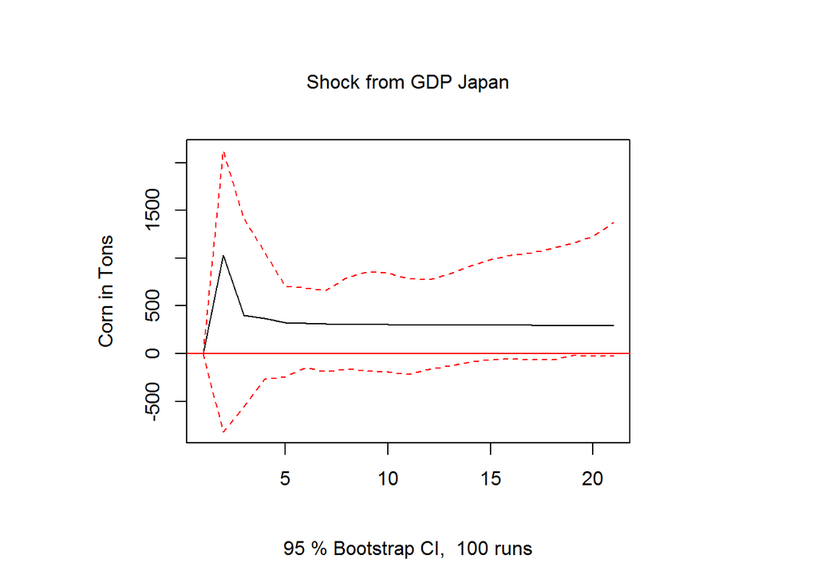

```r
GDPJapan_IRF = irf(ModelVAR_Corn, impulse = "GDP.Japan", response = "Corn", n.ahead = 20, boot = TRUE)
plot(GDPJapan_IRF, ylab = "Corn in Tons", main = "Shock from GDP Japan")
```

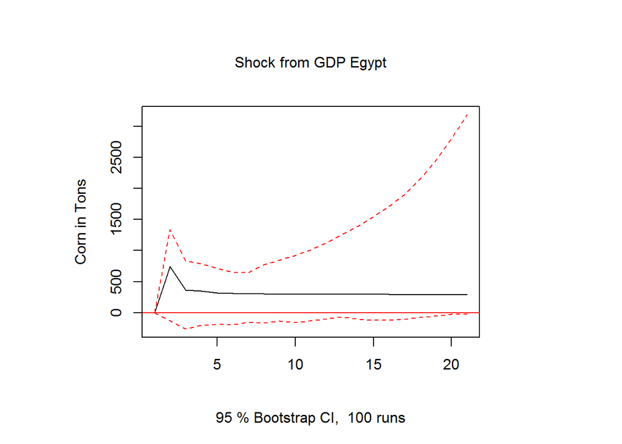

```r
GDPEgypt_IRF = irf(ModelVAR_Corn, impulse = "GDP.Egypt", response = "Corn", n.ahead = 20, boot = TRUE)
plot(GDPEgypt_IRF, ylab = "Corn in Tons", main = "Shock from GDP Egypt")
```

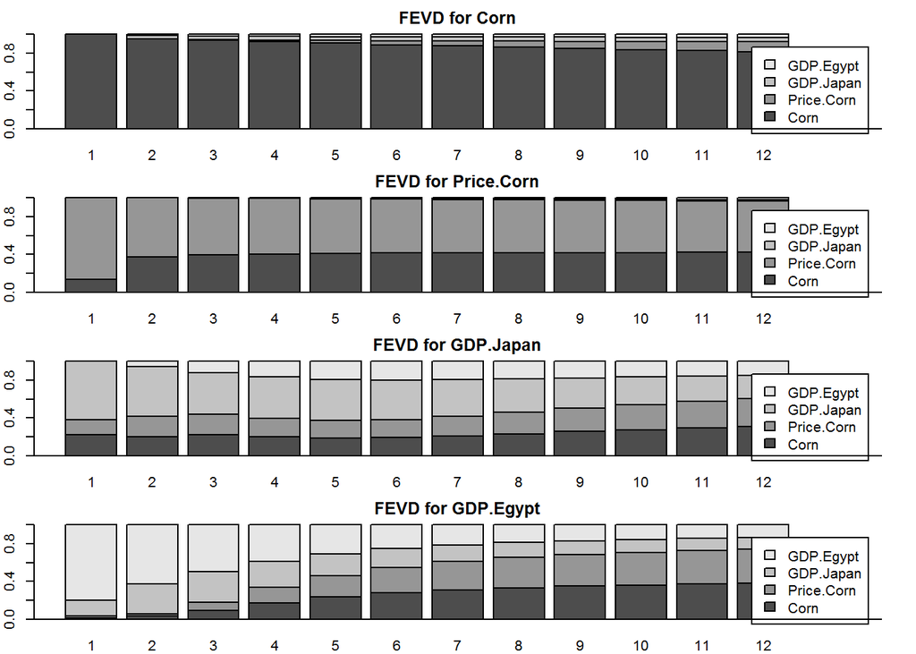

```r
# Variance decomposition - How much these variables are influenced by shocks
FEVD1 = fevd(ModelVAR_Corn, n.ahead = 12)
par(mar = rep(2, 4))
plot(FEVD1)
```

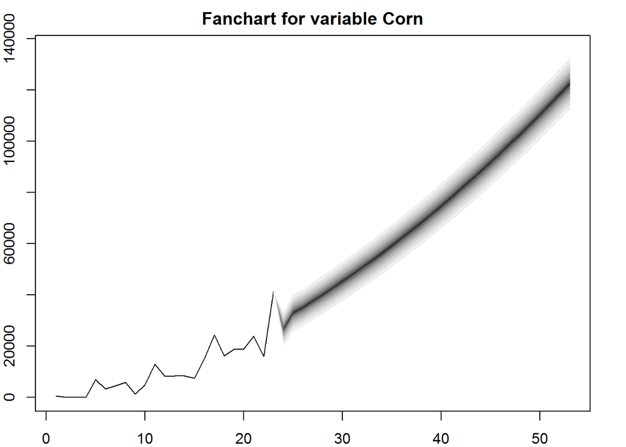

```r
# Var forecasting
pred_VAR = predict(ModelVAR_Corn, n.ahead = 30, ci = 0.95)
fanchart(pred_VAR, names = "Corn")
```

For the Corn VAR Model we can notice the stability through the non rejection of the null hypothesis from the tests of serial autocorrelation, heterocedasticity and normality distribution of the residuals. We also note that there’s no structural breaks in the residuals.